# Els esdeveniments de campanya i la intenció de vot

Què ens diu el tracking diari de 40dB sobre la primera setmana de campanya del 29-N

Autors/es

Jordi Muñoz

Claude

Publicat

20 de novembre del 2026

Versión en castellano · English version

## Resum

La primera setmana de campanya de les eleccions generals del 29 de novembre ha mogut poc la intenció de vot. La majoria d’esdeveniments que han ocupat els mitjans, com la vaga general per l’habitatge, les càrregues policials, el programa del PSOE o la notícia que la dona d’Abascal havia cobrat el bo social tèrmic, no deixen cap rastre visible en les enquestes diàries de 40dB.

L’excepció és el 13 de novembre, el dia que va començar oficialment la campanya. Aquell dia Vox va presentar el seu programa, Santiago Abascal va cancel·lar a última hora una entrevista amb el youtuber Jordi Wild i laSexta va emetre el primer debat. Entre els enquestats dels dies posteriors, Vox té uns 3,9 punts menys d’intenció de vot que entre els dels dies anteriors, i la proporció que considera Abascal el millor president baixa uns 4,5 punts. Una part d’aquesta pèrdua torna al PP, que recupera alguns dels seus votants del 2023 que havien passat a Vox, i el PSOE també guanya terreny, tot i que cap de les dues pujades no és tan sòlida com la caiguda de Vox. La caiguda de Vox sembla més intensa entre els homes joves, tot i que aquesta estimació és poc precisa.

No podem saber quin dels esdeveniments del 13 de novembre ho ha provocat, perquè tots van passar el mateix dia. Les enquestes diàries només detecten canvis grans, de quatre o cinc punts; els efectes més petits hi passen desapercebuts. Els detalls de les dades, el mètode i totes les comprovacions són a l’annex tècnic.

## 1 Què ha passat durant la primera setmana de campanya

La cobertura periodística tendeix a tractar cada dia de campanya com a decisiu: un debat, una relliscada o una entrevista cancel·lada es llegeixen com a punts d’inflexió. La ciència política n’ha estat tradicionalment més escèptica. La visió dominant, que resumeix Shaw (1999), és que els esdeveniments de campanya rarament tenen efectes forts, perquè la majoria de votants hi presten poca atenció, decideixen a partir de senyals partidistes i de l’estat de l’economia, i reben informació equilibrada de les campanyes rivals. L’anàlisi del mateix Shaw sobre les presidencials dels Estats Units entre 1952 i 1992 matisa aquesta visió: alguns esdeveniments, com els debats i les convencions, van produir canvis significatius i relativament duradors, mentre que la majoria van tenir efectes nuls o passatgers, i analitzar-los tots junts amaga els que sí que importen. La pregunta, doncs, és quins esdeveniments d’aquesta campanya, si n’hi ha cap, han mogut els votants.

### 1.1 Una campanya estable

40dB entrevista cada dia unes 500 persones noves per a *El País* i la SER (40dB 2026b). El 17 de novembre *El País* en va publicar l’estimació de vot amb el titular [«Vox se frena y cede terreno al PP»](https://elpais.com/espana/elecciones-generales/2026-11-17/vox-se-frena-y-cede-terreno-al-pp.html) (El País 2026). Aquí treballem amb les respostes individuals de les enquestes: si comparem les de dies successius, podem veure si l’opinió es mou després de cada esdeveniment. La Figura 1 mostra la intenció de vot dels principals partits a cada mostra diària, des de l’enquesta preelectoral del 2 al 4 de novembre fins al 19 de novembre.

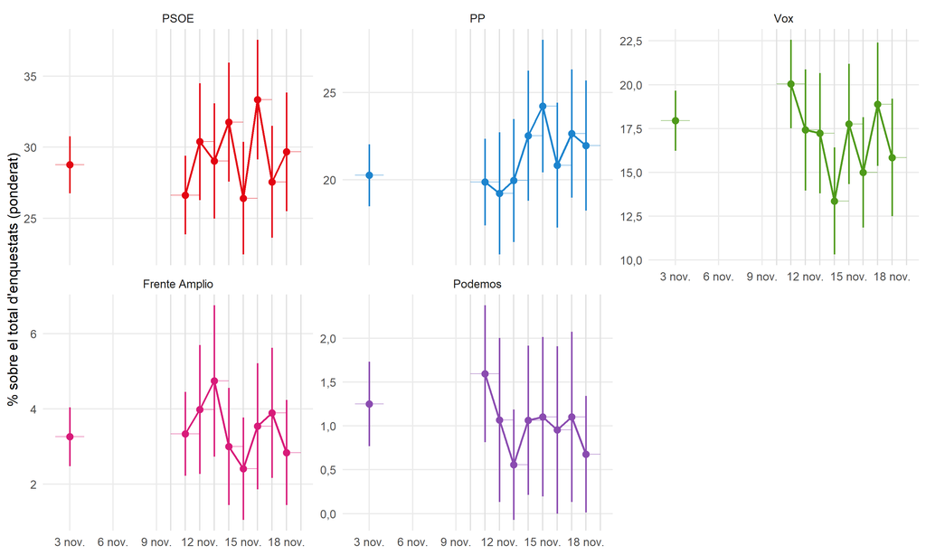

Figura 1: Intenció de vot directa (percentatge sobre el total d’enquestats). Cada punt és una mostra diferent; la línia vertical de cada punt indica el marge d’error i la línia horitzontal, els dies en què es van fer les entrevistes. Les línies grises verticals marquen els dies amb esdeveniments rellevants.

Les línies es mouen, però la major part d’aquests moviments són soroll: amb 500 entrevistes, una estimació del 20 % té un marge d’error d’uns 3,5 punts amunt o avall, i una del 30 %, d’uns 4 punts. Frente Amplio i Podemos es mantenen dins d’aquest marge tota la setmana. El moviment més clar és la caiguda de Vox a partir del 14 de novembre: arriba al mínim (13,4 %) entre el 14 i el 15 i des d’aleshores es manté per sota del seu nivell del 10 al 12 de novembre, tot i que entre el 17 i el 18 es recupera fins a un 18,9 %, a prop d’on havia començat, i entre el 18 i el 19 torna a baixar a un 15,8 %. El PP passa d’un 19,9 % entre el 10 i el 12 de novembre a un 24,2 % entre el 15 i el 16, torna a baixar a un 20,8 % entre el 16 i el 17 i se situa en un 22,7 % i un 22,0 % en les dues mostres següents. El PSOE puja i baixa d’un dia a l’altre i arriba a la xifra més alta, un 33,4 %, entre el 16 i el 17 de novembre.

### 1.2 El 13 de novembre, Vox retrocedeix i el PP recupera votants

El 13 de novembre va començar oficialment la campanya. Vox va presentar un programa centrat en la deportació de migrants i la “prioritat nacional” en l’accés a l’habitatge. Abascal va cancel·lar l’entrevista que tenia programada amb Jordi Wild, unes hores abans de gravar-la, mentre que Sánchez, Feijóo i Colau sí que hi van participar; la decisió va ser criticada fins i tot per veus properes a Vox. A la nit, laSexta va emetre el debat econòmic entre els portaveus dels quatre grans partits.

La Figura 2 compara les 1.000 persones entrevistades entre el 10 i el 12 de novembre amb les 2.500 entrevistades entre el 14 i el 19. La intenció de vot a Vox passa d’un 20,0 % a un 16,2 %, i la proporció que veu Abascal com el millor president, d’un 21,1 % a un 16,6 %. El PP puja d’un 19,9 % a un 22,4 %, i Feijóo com a millor president, d’un 21,0 % a un 22,8 %. La caiguda de Vox i d’Abascal és el resultat més clar de les dades, i es manté amb totes les maneres alternatives de fer el càlcul que hem provat, tot i que quan es corregeix per les moltes comparacions que fem deixa de ser concloent per si sola. La pujada del PP és menys segura: es queda a les portes de la significació a l’especificació principal (p = 0,074) i només és significativa en 2 de les 8 especificacions. El mateix li passa al PSOE, que puja d’un 26,6 % a un 29,8 % (p = 0,071; significativa en 2 especificacions); la pujada de Sánchez com a millor president és dins del marge d’error.

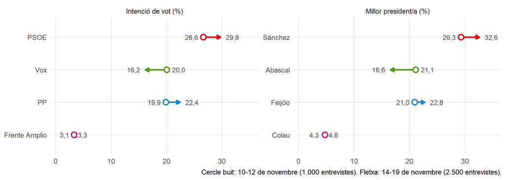

Figura 2: Intenció de vot i preferència per al millor president abans i després del 13 de novembre (percentatges ponderats).

Qui es mou? Entre els qui diuen haver votat el PP el 2023, la proporció que torna a votar el PP passa del 67 % al 76 %, i la que declara vot a Vox baixa uns 7 punts. Els votants de Vox del 2023 continuen igual de fidels. El que veiem, per tant, és el retorn al PP de votants del PP que s’havien passat a Vox, i no una pèrdua del nucli de Vox.

La caiguda sembla més intensa entre els homes de 18 a 34 anys: la intenció de vot a Vox en aquest grup passa d’un 30,3 % a un 21,9 %. És el que s’esperaria si la cancel·lació de l’entrevista amb Jordi Wild, que té una audiència sobretot jove i masculina, hagués perjudicat Abascal. La diferència, però, no és estadísticament significativa: es basa en només 103 entrevistes abans del 13 de novembre i 250 després, i s’ha de llegir amb prudència.

No podem atribuir el canvi a un sol esdeveniment. L’inici de campanya, el programa de Vox, la renúncia a l’entrevista i el debat de laSexta van coincidir el mateix dia, i les dades no permeten separar-los. A més, la mostra del 10 al 12 de novembre ja tenia un nivell de Vox una mica més alt que l’enquesta de principis de novembre; una part de la caiguda podria ser simplement un retorn a la normalitat. Fins i tot tenint-ho en compte, la caiguda de Vox es manté, tot i que és més petita (uns 2,5 punts).

### 1.3 La vaga general i les càrregues policials no mouen el vot

La vaga general per l’habitatge de l’11 de novembre, les càrregues policials contra els manifestants i el suport de Sánchez al ministre de l’Interior, Fernando Grande-Marlaska, l’endemà podien haver allunyat votants d’esquerra del PSOE cap a Frente Amplio o Podemos. No ho observem: entre els votants del PSOE i de Sumar del 2023, la intenció de vot a Frente Amplio i a Podemos gairebé no canvia (menys d’un punt) i el PSOE no perd terreny. En aquest cas l’única comparació possible és amb l’enquesta del 2 al 4 de novembre, feta una setmana abans i amb altres esdeveniments entremig, de manera que la conclusió és més feble. Un efecte petit, d’un o dos punts, no el podríem detectar.

### 1.4 Hernani i Canàries: impossible de separar del 13 de novembre

El 14 de novembre un grup de persones va atacar una carpa informativa del PP a Hernani, i aquell cap de setmana es va registrar un rècord d’arribades de pasteres a Canàries. Entre el 15 i el 19 de novembre el PP té uns 2,8 punts més que abans. La diferència és significativa a l’especificació principal (p = 0,037), però no després de corregir per comparacions múltiples, i és impossible separar-la de l’augment que ja havia començat el dia 13, perquè el grup de comparació es va entrevistar fins a aquell dia. Tampoc no podem comprovar si l’efecte és més gran al País Basc o a Canàries, perquè en una sola mostra diària hi ha com a màxim 34 entrevistes de cadascuna d’aquestes comunitats.

### 1.5 15 de novembre: el programa del PSOE

El 15 de novembre el PSOE va presentar el seu programa i Sánchez va titllar Abascal de «racista». Les 1.500 persones entrevistades entre el 16 i el 19 de novembre votarien el PSOE uns 2,0 punts més, i Vox uns 2,1 punts menys, que les entrevistades fins al 14. Els dos canvis van en la direcció esperada, però es basen en només 3 mostres diàries i són dins del marge d’error, fins i tot abans de corregir per comparacions múltiples. A més, el grup de comparació inclou els dies anteriors al 13 de novembre, de manera que aquestes diferències arrosseguen el canvi que va començar aquell dia.

### 1.6 16 i 17 de novembre: l’entrevista a Telecinco i el bo social de la dona d’Abascal

El 16 de novembre Lula va visitar la Moncloa, Frente Amplio va presentar el seu programa i, a la nit, Sánchez va concedir una entrevista tensa a Telecinco sobre la crisi de Ceuta. El 17 el Govern va aprovar la pujada de sou als funcionaris i la del salari mínim, i es va saber que la dona d’Abascal havia cobrat el bo social tèrmic, cosa que Abascal va defensar amb un atac groller als amics de Sánchez. Cap d’aquests esdeveniments no deixa un rastre detectable. Després del 16 de novembre, el PSOE canvia −0,3 punts (p = 0,851) i Vox, −0,2 punts (p = 0,891). Després del 17, Vox canvia −1,6 punts (p = 0,373) i Abascal com a millor president, −2,1 punts (p = 0,259): és la direcció que caldria esperar després de la notícia del bo, però dins del marge d’error. Aquesta última comparació es basa en una sola mostra diària (entre el 18 i el 19 de novembre), amb la qual només es detecten canvis d’uns 5 punts.

### 1.7 Com cal llegir aquests resultats

Els propers dies del tracking permetran avaluar el 18 de novembre, amb l’entrevista a Feijóo al pòdcast *El sentido de la birra* i la de Sánchez a Antena 3, i el 19, el dia del cara a cara entre Sánchez i Feijóo. Una enquesta de SocioMétrica per a *El Español* dona Feijóo com a guanyador del debat (64 % davant 32 %). Aquell mateix dia *El Mundo* va publicar una entrevista a Puigdemont sobre les negociacions amb el PSOE i es va conèixer un informe policial que atribueix a una logística prèvia l’entrada massiva a Ceuta. Els tres esdeveniments no es podran separar. També veurem si la caiguda de Vox es consolida o es reverteix.

## 2 Annex tècnic

Aquesta secció recull les dades, el disseny, les proves diagnòstiques i les estimacions detallades. Tota l’anàlisi es reprodueix amb `Rscript run_all.R` des de l’arrel del projecte, i les taules completes són a `output/tables/`.

### 2.1 Dades

40dB publica el tracking com a fitxers acumulatius (40dB 2026b). El fitxer del dia 2 conté les 1.000 entrevistes fetes del 10 al 12 de novembre i 500 més del 12 al 13. Els dies 3 i 4 hi afegeixen 500 entrevistes cadascun, i a partir del dia 5 la finestra és mòbil: entra el bloc més recent i surt el més antic. Com que l’identificador es renumera i la ponderació es recalcula en cada fitxer, hem reconstruït la mostra d’entrevistes úniques comparant el perfil complet de respostes de cada registre i la seva posició. Cada fitxer resulta ser exactament l’anterior, sense els blocs més antics, amb les entrevistes noves afegides al final. El resultat són 4.500 entrevistes úniques en 8 blocs de treball de camp (Figura 3). Hi afegim la primera enquesta preelectoral de 40dB (2-4 de novembre, 2.000 entrevistes), que comparteix les preguntes de vot amb el tracking i ens serveix com a referència anterior a la campanya (40dB 2026a). Totes les dades es poden descarregar del web d’*El País*: [preelectoral](https://ep00.epimg.net/infografias/encuestas40db/2026/11-preelectoral/2026_11_preelectoral_descargables.zip), [dia 2](https://ep00.epimg.net/infografias/encuestas40db/2026/11-tracking-electoral/40dB_tracking_dia02.zip), [dia 3](https://ep00.epimg.net/infografias/encuestas40db/2026/11-tracking-electoral/40dB_tracking_dia03.zip), [dia 4](https://ep00.epimg.net/infografias/encuestas40db/2026/11-tracking-electoral/40dB_tracking_dia04.zip), [dia 5](https://ep00.epimg.net/infografias/encuestas40db/2026/11-tracking-electoral/40dB_tracking_dia05.zip), [dia 6](https://ep00.epimg.net/infografias/encuestas40db/2026/11-tracking-electoral/40dB_tracking_dia06.zip), [dia 7](https://ep00.epimg.net/infografias/encuestas40db/2026/11-tracking-electoral/40dB_tracking_dia07.zip), [dia 8](https://ep00.epimg.net/infografias/encuestas40db/2026/11-tracking-electoral/40dB_tracking_dia08.zip).

Les dades no inclouen la data ni l’hora de cada entrevista. Cada bloc diari ocupa dos dies naturals (per exemple, del 13 al 14 de novembre), de manera que un esdeveniment del 13 de novembre pot ser anterior o posterior a les entrevistes dels blocs 2 i 3.

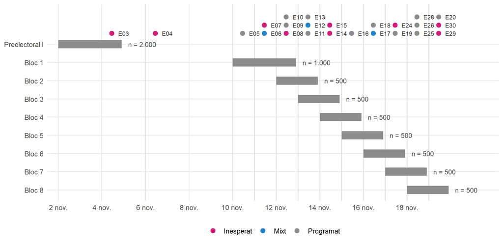

Figura 3: Blocs de treball de camp i esdeveniments. Cada barra és un bloc de mostra independent; els punts marquen els esdeveniments segons si eren inesperats, programats o mixtos (vegeu la Taula 1).

40dB fa servir quotes de sexe per edat, comunitat autònoma, mida del municipi i classe social. Hem ponderat cada bloc per separat amb un *raking* cap als mateixos marginals poblacionals, presos del fitxer ponderat del dia 4, perquè les comparacions entre dies no depenguin de quin fitxer prové cada entrevista. Els pesos són poc dispersos (efecte de disseny d’entre 1,02 i 1,07).

Hem trobat 291 entrevistes del tracking que són còpies exactes d’una altra en les 31 variables (edat exacta, província, deu probabilitats de vot…), gairebé sempre en un dia de treball de camp diferent. La proporció creix amb el temps, des d’un 1,8 % del bloc 1 fins a entre un 7 % i un 10 % de cada bloc a partir del 3. Probablement són registres duplicats o panelistes reentrevistats. Les mantenim a l’anàlisi principal i les excloem en una prova de robustesa.

### 2.2 Disseny

Seguim el disseny d’esdeveniments inesperats durant el treball de camp (UESD, Muñoz et al. 2020), que compara els enquestats entrevistats abans i després d’un esdeveniment. La interpretació causal depèn de dos supòsits. El primer és l’**exclusió**: el moment de l’entrevista només afecta el resultat a través de l’esdeveniment. En una campanya és un supòsit exigent, perquè cada dia hi ha diversos esdeveniments, cadascun genera reaccions (esdeveniments col·laterals) i el vot pot seguir tendències pròpies. El segon és la **ignorabilitat temporal**: el dia de l’entrevista ha de ser independent dels resultats potencials. El tracking l’afavoreix, perquè cada bloc és una mostra de quotes nova i completa, semblant a un *rolling cross-section* (Johnston i Brady 2002), però en un panell en línia els qui responen en un dia concret podrien diferir dels qui responen un altre dia.

La majoria d’esdeveniments de campanya no són inesperats en el sentit estricte del UESD: els debats, l’inici de la campanya i els programes estaven anunciats, i els seus efectes es podrien anticipar. Classifiquem cada esdeveniment com a inesperat, programat o mixt (Taula 1).

Per a cada dia amb esdeveniments, un bloc és *pre* si va acabar abans d’aquell dia i *post* si va començar després. Els blocs que contenen el dia de l’esdeveniment s’exclouen de l’estimació principal. Els esdeveniments d’un mateix dia s’estimen conjuntament com un **dia d’esdeveniments**. Les estimacions són efectes d’intenció de tractar (ITT): no sabem qui es va assabentar de cada esdeveniment, i el tracking no té cap pregunta sobre el problema més important que permeti una comprovació indirecta de l’exposició.

El model principal és una regressió lineal ponderada de cada indicador sobre una variable *post*, amb errors estàndard HC2 i controls per les variables de quota i el nivell d’estudis, totes anteriors al tractament. El record de vot del 2023 no hi entra: tendeix a ajustar-se a la preferència actual i, per tant, un esdeveniment el pot alterar, cosa que introduiria biaix posterior al tractament (Montgomery et al. 2018). El fem servir com a control en una especificació alternativa i com a resultat placebo. Fins al 12 de novembre no hi ha cap bloc del tracking completament anterior als esdeveniments, i el grup *pre* és l’enquesta preelectoral; aquestes comparacions, entre enquestes diferents i amb esdeveniments intermedis, són més febles. Els valors *q* corregeixen les comparacions múltiples dins de cada especificació (Benjamini i Hochberg 1995).

### 2.3 Esdeveniments

Taula 1: Esdeveniments durant el treball de camp i blocs de comparació. * Data aproximada. La llista completa, amb descripcions i fonts, és a events/events_29N.csv.

| ID | Data | Esdeveniment | Tipus | Blocs abans | Blocs després |
| --- | --- | --- | --- | --- | --- |
| E03 | 4 nov.* | Dimissió del ministre Puente | Inesperat | — | 1, 2, 3, 4, 5, 6, 7, 8 |
| E04 | 6 nov. | Zapatero continua investigat (Plus Ultra) | Inesperat | 0 | 1, 2, 3, 4, 5, 6, 7, 8 |
| E05 | 10 nov. | Programa del PP | Programat | 0 | 2, 3, 4, 5, 6, 7, 8 |
| E06 | 11 nov. | Vaga general per l’habitatge i càrregues policials | Mixt | 0 | 2, 3, 4, 5, 6, 7, 8 |
| E07 | 11 nov. | Pròrroga de la investigació a Zapatero | Inesperat | 0 | 2, 3, 4, 5, 6, 7, 8 |
| E08 | 12 nov. | Marlaska obre una investigació; Sánchez li dona suport | Inesperat | 0 | 3, 4, 5, 6, 7, 8 |
| E09 | 12 nov. | Votació dels decrets d’habitatge | Programat | 0 | 3, 4, 5, 6, 7, 8 |
| E10 | 12 nov. | Macroenquesta del CIS | Programat | 0 | 3, 4, 5, 6, 7, 8 |
| E11 | 13 nov. | Inici oficial de la campanya; programa de Vox | Programat | 0, 1 | 4, 5, 6, 7, 8 |
| E12 | 13 nov. | Entrevistes de Jordi Wild; Abascal hi renuncia | Mixt | 0, 1 | 4, 5, 6, 7, 8 |
| E13 | 13 nov.* | Debat econòmic a laSexta | Programat | 0, 1 | 4, 5, 6, 7, 8 |
| E14 | 14 nov.* | Agressió a un acte del PP a Hernani | Inesperat | 0, 1, 2 | 5, 6, 7, 8 |
| E15 | 14 nov.* | Rècord d’arribades de pasteres a Canàries | Inesperat | 0, 1, 2 | 5, 6, 7, 8 |
| E16 | 15 nov. | Programa del PSOE; Sánchez titlla Abascal de ‘racista’ | Programat | 0, 1, 2, 3 | 6, 7, 8 |
| E17 | 16 nov. | Lula a la Moncloa; programa de Frente Amplio; informe del CNI sobre Ceuta | Mixt | 0, 1, 2, 3, 4 | 7, 8 |
| E18 | 16 nov.* | Entrevista a Sánchez a Telecinco (Ceuta) | Programat | 0, 1, 2, 3, 4 | 7, 8 |
| E19 | 17 nov. | Pujada de sou als funcionaris i del salari mínim | Programat | 0, 1, 2, 3, 4, 5 | 8 |
| E24 | 17 nov. | La dona d’Abascal cobra el bo social tèrmic | Inesperat | 0, 1, 2, 3, 4, 5 | 8 |
| E25 | 18 nov. | Entrevista a Feijóo al pòdcast El sentido de la birra | Programat | 0, 1, 2, 3, 4, 5, 6 | — |
| E26 | 18 nov. | Entrevista a Sánchez a Antena 3 | Programat | 0, 1, 2, 3, 4, 5, 6 | — |
| E28 | 18 nov. | La Diputació Permanent convalida set decrets llei | Programat | 0, 1, 2, 3, 4, 5, 6 | — |
| E29 | 19 nov. | Entrevista a Puigdemont a El Mundo | Inesperat | 0, 1, 2, 3, 4, 5, 6, 7 | — |
| E30 | 19 nov. | Informe policial: l’entrada massiva a Ceuta va ser planificada | Inesperat | 0, 1, 2, 3, 4, 5, 6, 7 | — |
| E20 | 19 nov. | Cara a cara Sánchez–Feijóo | Programat | 0, 1, 2, 3, 4, 5, 6, 7 | — |

El 10 i l’11 de novembre comparteixen grups de comparació i tenen estimacions idèntiques. Els esdeveniments del 18 i 19 de novembre encara no tenen cap bloc posterior.

### 2.4 Diagnòstics

Taula 2: Diagnòstics per dia d’esdeveniments. Balanç conjunt: prova de Wald de les covariables no de quota i el record de vot com a predictors de ser entrevistat després. NS/NC: diferència post − pre en punts (valor p). Potència: probabilitat de detectar un efecte de 5 punts en la intenció de vot a Vox.

| Dia | Grup pre | n pre/post | Balanç conjunt | Placebos p<0,05 | NS/NC intenció | NS participació | Potència (5 p.) |
| --- | --- | --- | --- | --- | --- | --- | --- |
| 11 nov. E06, E07 | Preelectoral I | 2000/3500 | χ²(17) = 18,0, p = 0,392 | 0/5 | −0,4 (0,28) | −0,1 (0,84) | 1,00 |
| 12 nov. E08, E09, E10 | Preelectoral I | 2000/3000 | χ²(17) = 20,4, p = 0,254 | 1/5 | −0,3 (0,42) | 0,0 (0,91) | 0,99 |
| 13 nov. E11, E12, E13 | Tracking | 1000/2500 | χ²(17) = 19,8, p = 0,285 | 0/5 | −0,7 (0,19) | +0,6 (0,17) | 0,92 |
| 14 nov. E14, E15 | Tracking | 1500/2000 | χ²(17) = 23,7, p = 0,129 | 1/5 | −0,2 (0,63) | +0,7 (0,10) | 0,96 |
| 15 nov. E16 | Tracking | 2000/1500 | χ²(17) = 25,2, p = 0,091 | 0/5 | 0,0 (0,94) | +0,2 (0,55) | 0,97 |
| 16 nov. E17, E18 | Tracking | 2500/1000 | χ²(17) = 18,7, p = 0,343 | 0/5 | 0,0 (0,93) | 0,0 (0,99) | 0,93 |
| 17 nov. E19, E24 | Tracking | 3000/500 | χ²(17) = 16,2, p = 0,507 | 0/5 | +0,2 (0,82) | −0,4 (0,45) | 0,78 |

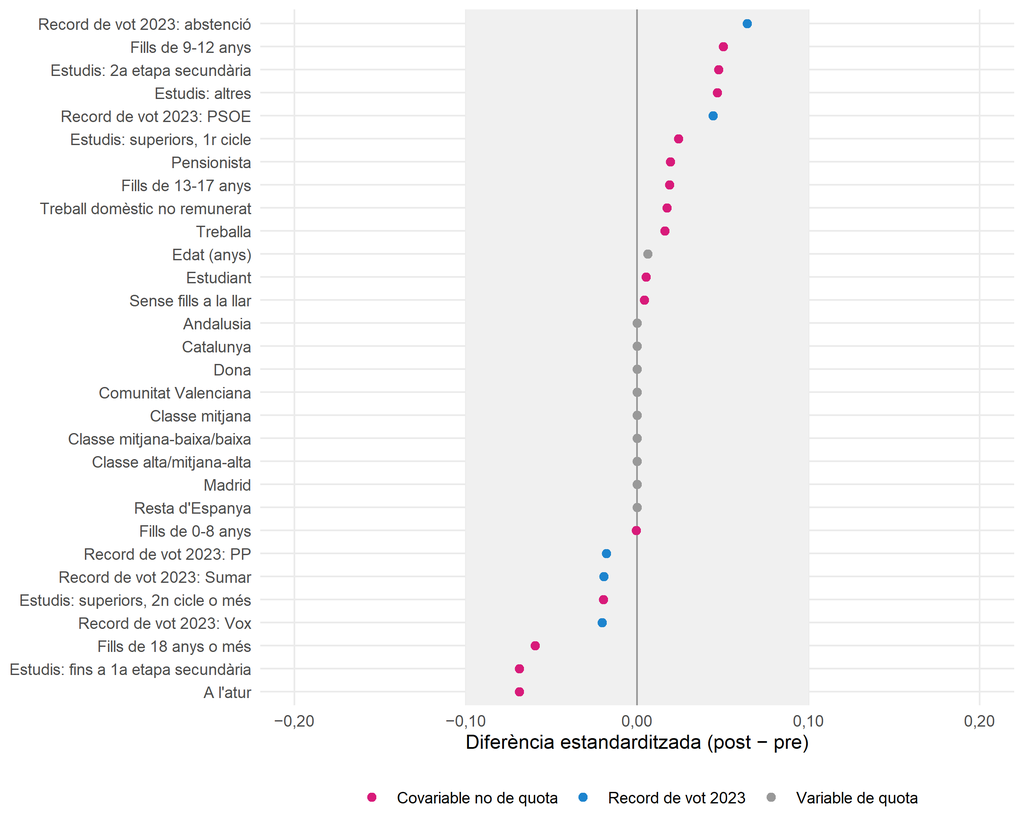

Figura 4: Balanç de covariables entre els grups pre (bloc 1) i post (blocs 4 a 8) del 13 de novembre. La franja grisa marca diferències estandarditzades inferiors a 0,1.

**No-resposta parcial.** La proporció que es nega a declarar la intenció de vot és estable. La que no sap si anirà a votar creix lleugerament després del 13 i el 14 de novembre (d’un 1 % a un 2 %, aproximadament), però la diferència no és significativa.

**Estabilitat del període previ.** La prova placebo de dividir el grup de control per la mediana de dies no és possible, perquè el bloc 1 no té dates individuals. Com a alternativa, comparem el bloc 1 amb l’enquesta preelectoral: la diferència de Vox és de +2,1 punts (p = 0,171), no significativa però en la direcció que podria inflar la caiguda posterior.

**Potència.** L’efecte mínim detectable amb una potència del 80 % per a la intenció de vot a Vox és de 4,1 punts el 13 de novembre i de 3,7 el 14. Cap prova global de diferències entre els 8 blocs del tracking sobreviu a la correcció per comparacions múltiples (*q* mínim = 0,75; sense corregir, Vox p = 0,042 i Abascal com a millor president p = 0,077).

### 2.5 Resultats detallats

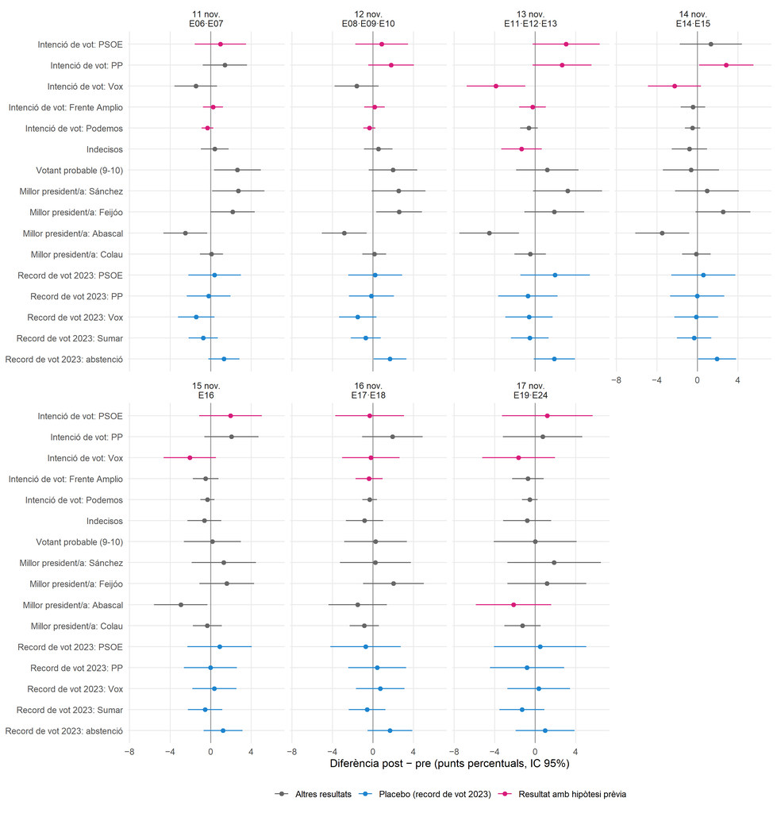

Figura 5: Diferències post − pre per dia d’esdeveniments (especificació principal). Per a l’11 i el 12 de novembre el grup pre és l’enquesta preelectoral; a partir del 13, els blocs del tracking anteriors a l’esdeveniment. Magenta: indicadors amb hipòtesi prèvia; blau: placebos.

Taula 3: 13 de novembre: diferències entre els enquestats del 14-19 i del 10-12 de novembre. Pre: percentatge al bloc 1. Regressió lineal ponderada amb controls de quota i estudis; errors HC2; q: valors de Benjamini-Hochberg.

| Indicador | Pre (%) | Diferència (punts) | IC 95% | p | q |
| --- | --- | --- | --- | --- | --- |
| Intenció de vot: PSOE | 26,6 | +3,1 | [−0,3; 6,4] | 0,071 | 0,55 |
| Intenció de vot: PP | 19,9 | +2,7 | [−0,3; 5,6] | 0,074 | 0,55 |
| Intenció de vot: Vox | 20,0 | −3,9 | [−6,8; −1,0] | 0,009 | 0,26 |
| Intenció de vot: Frente Amplio | 3,3 | −0,3 | [−1,6; 1,1] | 0,702 | 0,85 |
| Intenció de vot: Podemos | 1,6 | −0,6 | [−1,5; 0,3] | 0,163 | 0,64 |
| Indecisos | 8,5 | −1,3 | [−3,4; 0,7] | 0,189 | 0,64 |
| Votant probable (9-10) | 75,8 | +1,2 | [−1,9; 4,3] | 0,446 | 0,74 |
| Millor president/a: Sánchez | 29,3 | +3,2 | [−0,2; 6,6] | 0,065 | 0,55 |
| Millor president/a: Feijóo | 21,0 | +1,9 | [−1,1; 4,8] | 0,211 | 0,64 |
| Millor president/a: Abascal | 21,1 | −4,5 | [−7,5; −1,6] | 0,002 | 0,18 |
| Millor president/a: Colau | 4,8 | −0,5 | [−2,0; 1,1] | 0,533 | 0,78 |

Les caigudes d’Abascal com a millor president (−4,5 punts (p = 0,002; q = 0,18)) i de Vox (−3,9 punts (p = 0,009; q = 0,26)) tenen els valors *q* més baixos del 13 de novembre, però amb 75 proves a l’especificació principal cap no baixa de 0,1. La del PSOE és de +3,1 punts (p = 0,071; q = 0,55) i la del PP, de +2,7 punts (p = 0,074; q = 0,55). La caiguda de Vox i d’Abascal és significativa en les 8 especificacions de la Figura 6. Quan els blocs que contenen el dia 13 es tracten com a posteriors, l’efecte sobre Vox s’atenua fins a −3,5 punts (p = 0,013), i amb l’enquesta preelectoral afegida al grup *pre* és de −2,5 punts (p = 0,017). El guany del PP és significatiu en 2 de les 8 especificacions, i el del PSOE, en 2.

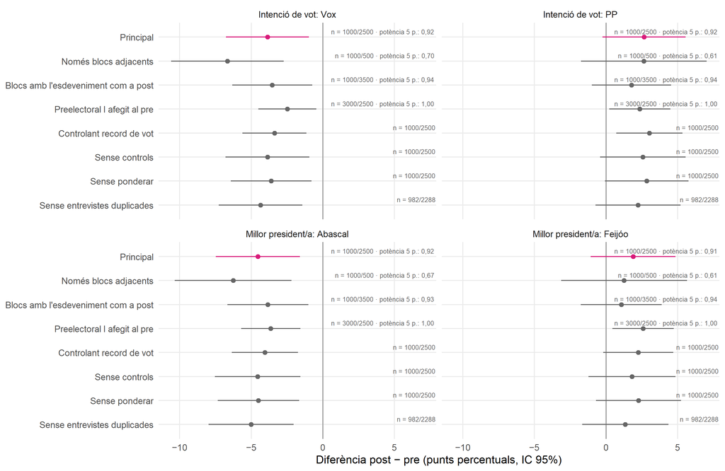

Figura 6: Robustesa de les estimacions del 13 de novembre. Per a cada especificació s’indica la mida dels grups pre/post i, per a les variacions de finestra, la potència per detectar un efecte de 5 punts.

**Heterogeneïtat.** La Figura 7 mostra els efectes en grups definits abans d’estimar. Entre els homes de 18 a 34 anys, la diferència en la intenció de vot a Vox el 13 de novembre és de −6,7 punts (p = 0,211) (103 enquestats pre i 250 post), concentrada sobretot al bloc 4. Entre els votants del PSOE i Sumar del 2023, la diferència en la intenció de vot a Frente Amplio després de la vaga és de +0,6 punts (p = 0,559) i en la del PSOE, de +1,7 punts (p = 0,430). Per al 14 de novembre, la diferència per al PP és de +2,8 punts (p = 0,037), però el grup *pre* inclou blocs anteriors al 13 de novembre i hereta la tendència d’aquell dia, una violació del supòsit d’exclusió per tendència temporal (Muñoz et al. 2020). Les falsacions regionals (H4 i H5) només tenen 122 i 88 casos al grup post. Les heterogeneïtats per record de vot (H1, H3) i els fluxos de vot s’han de llegir amb cautela, perquè el moderador podria estar afectat pel tractament.

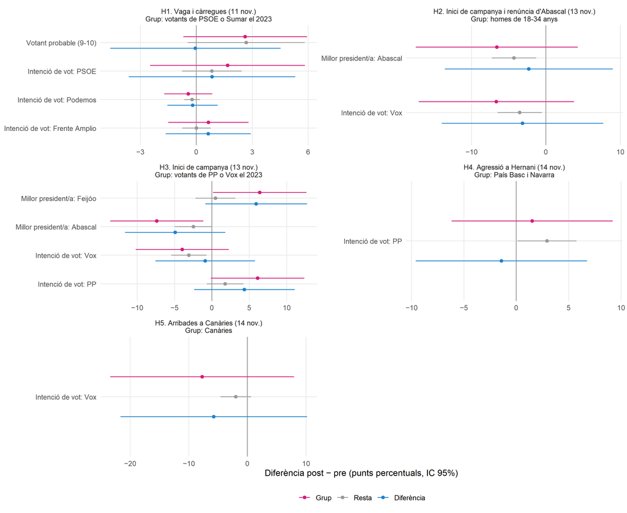

Figura 7: Efectes per grups definits a priori. Grup: diferència post − pre dins del grup; Resta: fora del grup; Diferència: interacció.

## Referències

40dB. 2026a. *Encuesta preelectoral I, noviembre de 2026*. Microdatos, cuestionario, nota metodológica, tablas e informe. Encuesta para El País y la Cadena SER. https://ep00.epimg.net/infografias/encuestas40db/2026/11-preelectoral/2026_11_preelectoral_descargables.zip.

40dB. 2026b. *Tracking electoral 29-N, días 2 a 5*. Microdatos, cuestionarios, notas metodológicas, tablas e informes diarios (40dB_tracking_dia02.zip a dia05.zip). Encuesta para El País y la Cadena SER. https://ep00.epimg.net/infografias/encuestas40db/2026/11-tracking-electoral/40dB_tracking_dia05.zip.

Benjamini, Yoav, i Yosef Hochberg. 1995. «Controlling the False Discovery Rate: A Practical and Powerful Approach to Multiple Testing». *Journal of the Royal Statistical Society: Series B (Methodological)* 57 (1): 289-300. https://doi.org/10.1111/j.2517-6161.1995.tb02031.x.

El País. 2026. «Vox se frena y cede terreno al PP». *El País*, novembre 17. https://elpais.com/espana/elecciones-generales/2026-11-17/vox-se-frena-y-cede-terreno-al-pp.html.

Johnston, Richard, i Henry E. Brady. 2002. «The Rolling Cross-Section Design». *Electoral Studies* 21 (2): 283-95. https://doi.org/10.1016/S0261-3794(01)00022-1.

Montgomery, Jacob M., Brendan Nyhan, i Michelle Torres. 2018. «How Conditioning on Posttreatment Variables Can Ruin Your Experiment and What to Do about It». *American Journal of Political Science* 62 (3): 760-75. https://doi.org/10.1111/ajps.12357.

Muñoz, Jordi, Albert Falcó-Gimeno, i Enrique Hernández. 2020. «Unexpected Event during Survey Design: Promise and Pitfalls for Causal Inference». *Political Analysis* 28 (2): 186-206. https://doi.org/10.1017/pan.2019.27.

Shaw, Daron R. 1999. «A Study of Presidential Campaign Event Effects from 1952 to 1992». *The Journal of Politics* 61 (2): 387-422. https://doi.org/10.2307/2647509.